# Lab 01 Report

Mudith Chathuranga Silva

4/7/2020

### 01. Let $y_1 ... y_n | \theta \sim Bern(\theta)$, and assume that you have obtained a sample with s = 5 successes in n = 20 trials. Assume a $Beta(\alpha_0, \beta_0)$ prior for $\theta$ and let $\alpha_0 = \beta_0 = 2$

#### (A) Draw random numbers from the posterior $\theta | y \sim Beta(\alpha_0 + s, \beta_0 + f), y = (y_1,...y_n)$ and verify graphically that the posterior mean and standard deviation converges to the true values as the number of random draws grows large.

Model :-

$$x_1 , ... , x_n | \theta \overset{iid}{\sim} Bern(\theta)$$

Prior :-

$$\theta \sim Beta(\alpha_0,\beta_0)$$
$$\theta \sim Beta(2,2)$$

Posterior :-

$$P(\theta | x_1,...,x_n) \propto P(x_1,...,x_n|\theta) * P(\theta)$$

$$P(\theta | x_1,...,x_n) \propto \theta^{s}(1 - \theta)^{f} * \theta^{\alpha - 1}(1 - \theta)^{\beta - 1}$$

$$P(\theta | x_1,...,x_n) \propto \theta^{s + \alpha - 1}(1 - \theta)^{f + \beta -1}$$

$$\theta \propto Beta(\alpha,\beta) \overset{x_1,..,x_n}{\to} \theta | x_1,...,x_n \sim Beta(\alpha + s, \beta + f)$$

$$\theta \propto Beta(2,2) \overset{x_1,..,x_n}{\to} \theta | x_1,...,x_n \sim Beta(2 + 5, 2 + 15)$$

$$\theta \propto Beta(2,2) \overset{x_1,..,x_n}{\to} \theta | x_1,...,x_n \sim Beta(7, 17)$$

```r
s = 5
f = 15
a0 = 2
b0 = 2

sample01 = rbeta(100,a0 + s, b0 + f)
sample02 = rbeta(1000,a0 + s, b0 + f)
sample03 = rbeta(10000,a0 + s, b0 + f)
sample04 = rbeta(100000,a0 + s, b0 + f)
```

True Mean and Variance for Beta Distribution is given by :-

$$E(\theta) = \frac{\alpha}{\alpha + \beta}$$

$$E(\theta) = \frac{7}{7 + 17}$$

$$E(\theta) = 0.2916$$

$$var(\theta) = \frac{\alpha \beta}{(\alpha + \beta)^{2} (\alpha + \beta + 1)}$$

$$var(\theta) = \frac{7 * 17}{(7 + 17)^{2} (7 + 17 + 1)}$$

$$var(\theta) = \frac{7 * 17}{(7 + 17)^{2} (7 + 17 + 1)}$$

$$var(\theta) = 0.008263$$

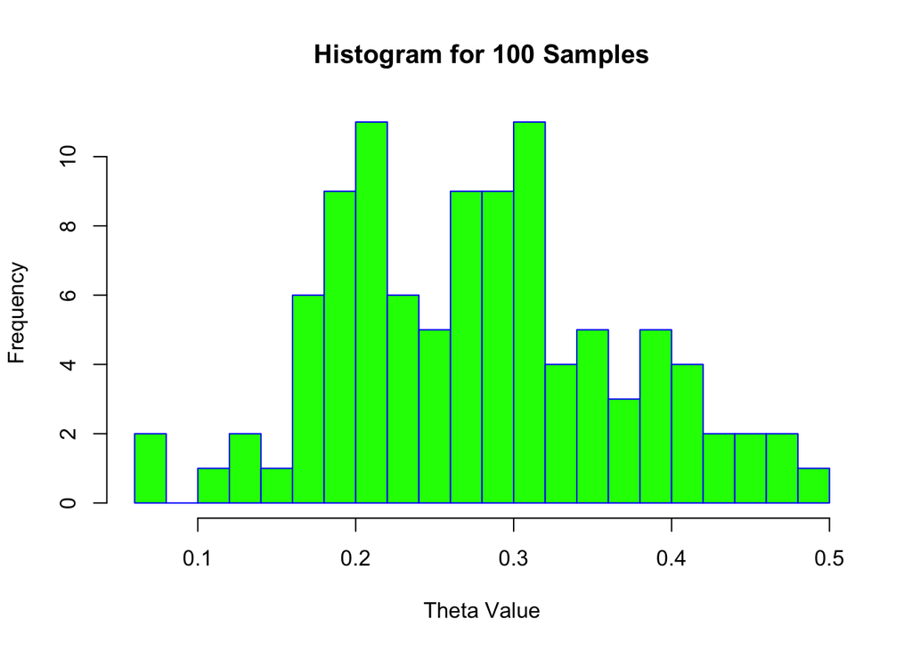

```r
hist(sample01,
     main = "Histogram for 100 Samples",
     xlab = "Theta Value",
     border = "blue",
     col = "green",
     breaks = 30)
```

```r
cat('Mean for 100 samples:- ', mean(sample01), '\n')
```

```
## Mean for 100 samples:-  0.2778094
```

```r
cat('Variance for 100 samples:- ', var(sample01), '\n')
```

```
## Variance for 100 samples:-  0.008226398
```

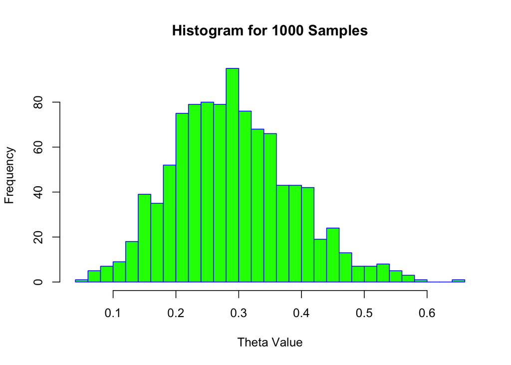

```r
hist(sample02,
     main = "Histogram for 1000 Samples",
     xlab = "Theta Value",
     border = "blue",
     col = "green",
     breaks = 30)
```

```r
cat('Mean for 1000 samples:- ', mean(sample02), '\n')
```

```
## Mean for 1000 samples:-  0.2895979
```

```r
cat('Variance for 1000 samples:- ', var(sample02), '\n')
```

```
## Variance for 1000 samples:-  0.009030048
```

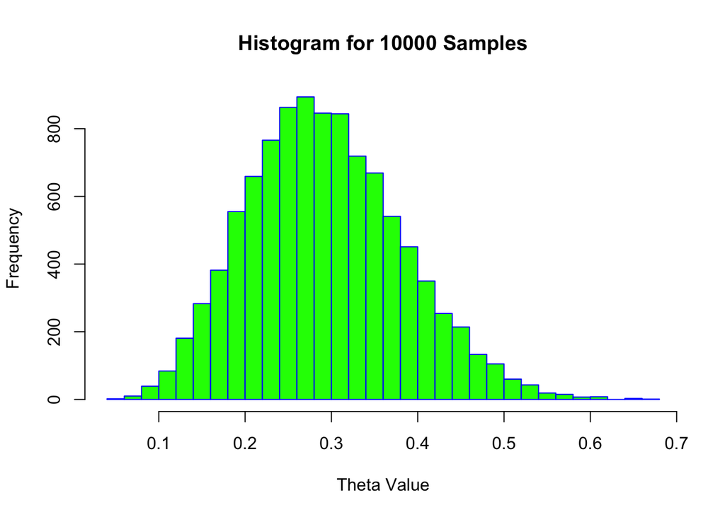

```r
hist(sample03,
     main = "Histogram for 10000 Samples",
     xlab = "Theta Value",
     border = "blue",
     col = "green",
     breaks = 30)
```

```r
cat('Mean for 10000 samples:- ', mean(sample03), '\n')
```

```
## Mean for 10000 samples:-  0.2922733
```

```r
cat('Variance for 10000 samples:- ', var(sample03), '\n')
```

```
## Variance for 10000 samples:-  0.008008267
```

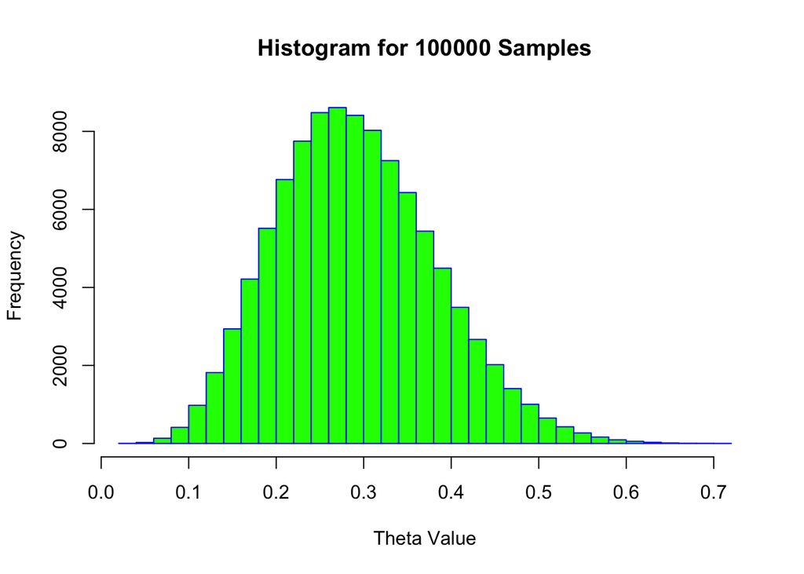

```r
hist(sample04,
     main = "Histogram for 100000 Samples",
     xlab = "Theta Value",
     border = "blue",
     col = "green",
     breaks = 30)
```

```r
cat('Mean for 100000 samples:- ', mean(sample04), '\n')
```

```
## Mean for 100000 samples:-  0.2914376
```

```r
cat('Variance for 100000 samples:- ', var(sample04), '\n')
```

```
## Variance for 100000 samples:-  0.008266359
```

It’s clear that Posterior Mean and Variance Converges to the true Mean and Variance when the number of random draw grows larger.

#### (B) Use simulation (nDraws = 10000) to compute the posterior probability $Pr(\theta > 0.3|y)$ and compare with the exact value [Hint: pbeta()].

```r
sampleProb = mean(sample03 > 0.3)
trueProb = 1 - pbeta(0.3,7,17) # pbeta gives p(theta < 0.3)

cat('Sample Probability :- ', sampleProb, '\n')
```

```
## Sample Probability :-  0.4436
```

```r
cat('True Probability :- ', trueProb, '\n')
```

```
## True Probability :-  0.4399472
```

True $Pr(\theta > 0.3|y)$ = 0.4399472 is so close to the Sample $Pr(\theta > 0.3|y)$ = 0.4436 for 10000 samples

#### (C) Compute the posterior distribution of the log-odds $\phi = log \frac{\theta}{1 - \theta}$ by simulation (nDraws = 10000). [Hint: hist() and density() might come in handy]

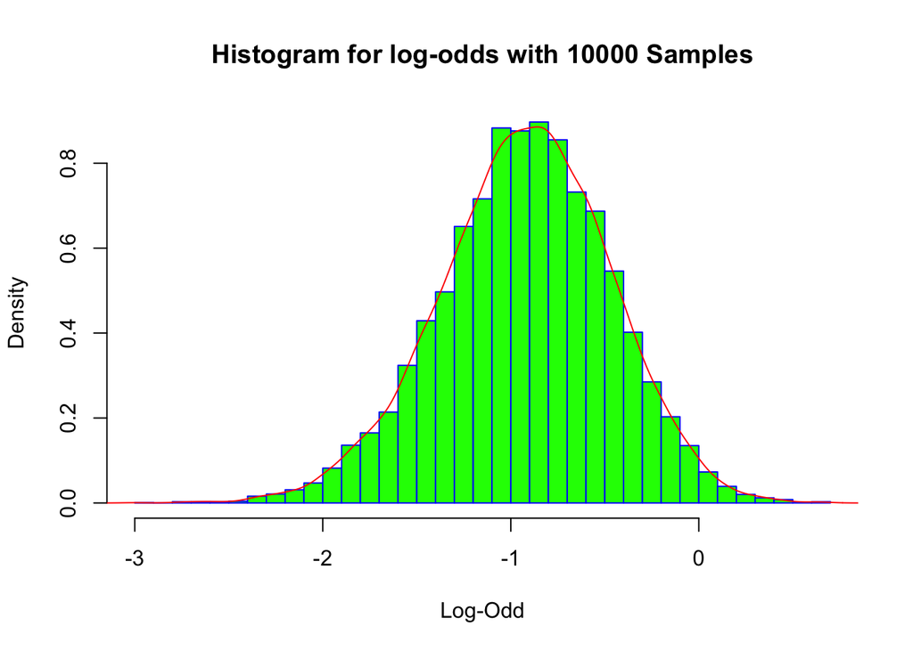

```r
log_odds = log(sample03 / (1 - sample03))
hist(log_odds,
     main = "Histogram for log-odds with 10000 Samples",
     xlab = "Log-Odd",
     border = "blue",
     col = "green",
     breaks = 30,
     probability = T)
lines(density(log_odds), lwd = 1, col = "red")
```